# Assignment 3 - The free position facility location problem

Federico Signoretta

18 May 2019

## The Problem

In this assignment we will look at the **Facility Location Problem**. The problem can be described in general terms as follows:

We must decide the placement of a facility that distributes a certain good to a group of consumers that need it.

The placement must to be chosen in order to **minimize** the total compound distance from the facility and the customers.

The following assumptions has to be taken into account:

1. The possible location for the facility is unknown, that is the problem is to find the right spot to build it.
2. The facility building costs are fixed and independent from the position of the building site.

Notice that in this scenario there is one possible decision to make:

- where to build the facility, that is find the position ($\chi$, $\upsilon$) that minimises the compound distance of the facility with respect to all custumers.

### Data

A file with the locations of the consumers can be found in the `Data` folder.

## Distance function

Given the position of the facility $f= (\chi, \upsilon)$ and of a consumer $p_i=(x_i, y_i)$ use the following formula to calculate the distance between them.

$$d(f,p_i) = log((\chi-x_i)^2+1) + log((\upsilon-y_i)^2+1)$$

## The assignment

### 1. Formulate the objective function to minimize for the described problem.

To satisfy the request about the location of the facility, we need to create a model that minimize the sum of the distance $d(f,p_i)$ for $i=1,\dots,100$:

$$min \big(\Delta(\chi, \nu)\big) = min \big( \sum_{i=1}^{100} d(f,p_i) \big) = min\big(\sum_{i=1}^{100} ( log[(\chi-x_i)^2+1] + log[(\upsilon-y_i)^2+1] )\big)$$

### 2. Express in analytical form the gradient for the objective to minimize.

In order to calculate the gradient of $\Delta(\chi,\nu)$, we first calculate the partial derivate with respect to $\chi$ and with respect to $\nu$:

- $$\frac{\partial(\Delta(\chi,\nu))}{\partial\chi} = 2\cdot \sum_{i=1}^{100} \frac{( \chi - x_i)}{(\chi - x_i)^2 +1}$$
- $$\frac{\partial(\Delta(\chi,\nu))}{\partial\nu} = 2\cdot \sum_{i=1}^{100} \frac{( \nu - y_i)}{(\nu - y_i)^2 +1}$$

So, the gradient will be:

$$\nabla (\Delta(\chi, \nu)) = \Bigg (\matrix{ \frac{\partial(\Delta(\chi,\nu))}{\partial\chi} \\ \frac{\partial(\Delta(\chi,\nu))}{\partial\nu}} \Bigg ) = 2\cdot \Bigg (\matrix{ \sum_{i=1}^{100} \frac{( \chi - x_i)}{(\chi - x_i)^2 +1} \\ \sum_{i=1}^{100} \frac{( \nu - y_i)}{(\nu - y_i)^2 +1}} \Bigg )$$

### 3. Implement the `Gradiend Descent method` and solve the problem with it.

```r
library(ggplot2)
library(magrittr)
library(Hmisc)
```

First, we define the functions to calculate:  
- the distance between two points $\Delta(\chi, \nu)= \sum_{i=1}^{100} d(f,p_i)$  
- the gradient of a function $\nabla (\Delta(\chi, \nu))$  
- the Euclidean norm $||(\chi, \nu)||= \sqrt{\chi^2 + \nu^2}$

```r
df <- read.csv("consumer_locations.csv", sep = ",")
X <- data.matrix(df, rownames.force = NA)

fn.dist <- function(X, par) return(sum(log((par[1]-X[,1])^2+1)) + sum(log((par[2]-X[,2])^2+1)))

# gradient function
fn.gr <- function(X, par) {
  g1 <- sum(2*(par[1]-X[,1])/((par[1]-X[,1])^2+1))
  g2 <- sum(2*(par[2]-X[,2])/((par[2]-X[,2])^2+1))
  return(c(g1,g2))
}

# euclidean norm function
fn.norma <- function(x) return(sqrt(sum((x)^2)))

# gradient descent function
gradientDescent <- function(X, par.init, fun.gr, lr, iters, tol){
  par <- matrix(NA, nrow = iters+1, ncol = 2)
  grad_dist <- matrix(NA, nrow = iters+1, ncol = 2)
  par[1,] <- par.init
  for(k in 1:iters){
    grad_dist[k,] <- fun.gr(X=X, par=par[k,])
    par[k+1,] <- par[k,] - lr*grad_dist[k,]
    if(fn.norma(grad_dist[k,])<=tol){
        return(par[k,])
    }
  }
  stringa <- "Non ho trovato il minimo"
  return(stringa)
}
```

We randomly take an initial point of $\chi$ and $\nu$ and we calculate the `Gradient Discent`:

```r
part <- c(runif(1,1,1000), runif(1,1,1000))
facility <- gradientDescent(X, par.init = part, fun.gr = fn.gr, lr = 0.1, iters = 1000, tol = 0.00001)
```

Now, we have two choices:

- using 1,000 different random initial points $(\chi,\nu)$ and finding the best one (i.e. the point with smaller distance $\Delta(\chi,\nu)$)

```r
repeat {
  facility <- gradientDescent(X, par.init = part, fun.gr = fn.gr, lr = 0.1, iters = 1000, tol = 0.00001)
  if (class(facility) == "numeric")
    break
}

d <- fn.dist(X, facility)
for (i in 1:1000) {
  par_init<- c(runif(1,1,1000), runif(1,1,1000))
  facility <- gradientDescent(X, par.init = par_init, fun.gr = fn.gr, lr = 0.1, iters = 1000, tol = 0.00001)
  if (class(facility) == "numeric") {
    if (fn.dist(X,facility) < d) {
        d <- fn.dist(X,facility)
        fac_optimal_r <- facility
    }
  }
}
print(c(facility = fac_optimal_r, distance = d))
```

```
## facility1 facility2  distance
##  310.1627  430.8702 2004.9642
```

Where the Euclidean norm is close to zero:

```r
fn.norma(fn.gr(X=X,fac_optimal_r))
```

```
## [1] 9.606775e-06
```

- using as initial point, one of the points of the dataset in an iterative way

```r
repeat {
  facility <- gradientDescent(X, par.init = part, fun.gr = fn.gr, lr = 0.1, iters = 1000, tol = 0.00001)
  if (class(facility) == "numeric")
    break
}

d <- fn.dist(X, facility)
for (i in 1:100) {
  par_init <- c(X[i,1],X[i,2])
  facility <- gradientDescent(X, par.init = par_init, fun.gr = fn.gr, lr = 0.1, iters = 1000, tol = 0.00001)
  if (class(facility) == "numeric") {
    if (fn.dist(X,facility) < d) {
        d <- fn.dist(X,facility)
        fac_optimal <- facility
    }
  }
}
print(c(facility = fac_optimal, distance = d))
```

```
## facility1 facility2  distance
##  310.1627  430.8703 2004.9642
```

Where the Euclidean norm is close to zero:

```r
fn.norma(fn.gr(X=X,fac_optimal))
```

```
## [1] 9.856868e-06
```

Both methods have null gradient and we obtain a local minimum given by $(\chi_{min},\nu_{min})=(310.1627 , 430.8703)$ with distance $\Delta_{min} = 2004.9642$

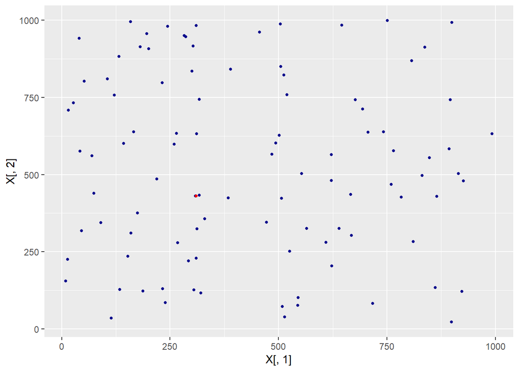

```r
fac_optimal_df <- as.data.frame(fac_optimal)
g <- ggplot() +
  # blue plot
    geom_point(data=df, aes(x = X[,1], y = X[,2]),fill="blue",colour="darkblue", size=1) +
  # red plot
    geom_point(data=fac_optimal_df, aes(x = fac_optimal_df[1,], y = fac_optimal_df[2,]), fill="red", colour="red", size=1)
g
```

### 4. Solve the problem with a package provided by R (for instance, using the function `optimr` within the package `optimx`). Note that it is not required to use the `gradient descent` algorithm to solve the problem, other algorithms can be used as well.

We solve the problem as well as before, but using the function `optimr`.  
In particular, we decide to use the method “CG” in the `optimr` that use the gradient function as well.

```r
library(curry)

fun.gr_1  <- curry(fun = fn.gr, X)
fun.dist <- curry(fun = fn.dist, X)

library(optimx)
strt <- part
ansfgh <- optimr(par = strt, fn = fun.dist, gr = fun.gr_1,method="CG")
opt_CG <- ansfgh


for (i in 1:100) {
  strt <- c(X[i,1],X[i,2])
  ansfgh <- optimr(par = strt, fn = fun.dist, gr = fun.gr_1,method="CG")
  if(ansfgh$value < opt_CG$value) {
    opt_CG <- ansfgh
  }

}
proptimr(opt_CG)
```

```
## Result  opt_CG   proposes optimum function value = 2004.964  at parameters
##        x        y
## 310.1627 430.8702
## After  61  fn evals, and  25  gr evals
## Termination code is  0 :
## ---------------------------------------
```

From the results it is possible to observe that both $f_{min}=(\chi_{min},\nu_{min})$ and $\Delta_{min}$ are more or less the same.

### 5. Implement the `Stochastic gradient descent` algorithm with mini-batches and use it to solve the problem.

We define the stochastic gradient descent function with mini-batches equal to $5\%$ of the whole dataset. In this function we create a sample of the dataset at each iteration and we calculate the gradient and the distance for each sample.  
During the creation of this function, we have decided to set a condition on the distance to guarantee the convergence of the method and to assure us that the point that the function is going to return is a minimum. If the distance calculated at the iteration i is smaller than the one at the iteration i-1, the parameter obtained at the iteration i, will be considered the optimal value, as well as its associated distance.

```r
# define stochastic gradient descent algorithm
stoch_gradDescent <- function(X, par.init, fun.gr, lr, iters){



  # Initialize a matrix to store values of par for each iteration
  parIter <- matrix(NA, nrow = iters, ncol = 2)
  distIter <- matrix(NA, nrow = iters, ncol = 1)
  parIter[1, ] <- par.init

  # now iterate using mini batches of randomly sampled  data, updating theta each step
  for (i in 2:iters) {

    xysamp <- as.matrix( X[sample(nrow(X), 5, replace = TRUE), ])
    parIter[i, ] <- parIter[i-1, ]- lr  * fun.gr(xysamp, parIter[i-1,])
    distIter[i] <- fn.dist(X, parIter[i,])

  }

  d_min <- fn.dist(X, parIter[1,])
  par_opt <- parIter[1,]
  for(i in 2:iters) {
    if( distIter[i] < d_min){
      d_min <- distIter[i]
      par_opt <- parIter[i,]
    }
  }
  return(c(par_opt = par_opt, d = d_min))
}
```

As before, we are going to find the solution $f_{min}$ with the lower distance $\Delta(\chi,\nu)$.  
Again, we are going to split the analysis in two cases, in which the initial points are different. (See point 3)

```r
part <- c(runif(1,1,1000), runif(1,1,1000))
result <- stoch_gradDescent(X = X, par.init = part, fun.gr = fn.gr,lr = 0.1, iters = 1000)
d_stoch <- result["d"]

for (i in 1:100) {
  part<- c(X[i,1],X[i,2])
  result <- stoch_gradDescent(X, part, fn.gr, 0.1,1000)

  if (result["d"] < d_stoch) {
    d_stoch <- result["d"]
    result_opt<- c(result["par_opt1"],result["par_opt2"])
  }
}


print(c(facility= result_opt, distance = d_stoch))
```

```
## facility.par_opt1 facility.par_opt2        distance.d
##          310.1637          430.8663         2004.9642
```

```r
part <- c(runif(1,1,1000), runif(1,1,1000))
result <- stoch_gradDescent(X = X, par.init = part, fun.gr = fn.gr,lr = 0.1, iters = 1000)
d_stoch <- result["d"]

for (i in 1:1000) {
  part <- c(runif(1,1,1000), runif(1,1,1000))
  result <- stoch_gradDescent(X, part, fn.gr, 0.1,1000)

  if (result["d"] < d_stoch) {
    d_stoch <- result["d"]
    result_opt<- c(result["par_opt1"],result["par_opt2"])
  }
}
print(c(facility= result_opt, distance = d_stoch))
```

```
## facility.par_opt1 facility.par_opt2        distance.d
##          311.1508          427.4670         2007.5047
```

As we expected, the results are very similar to the results obtained before. In this case, the performance are more or less the same because the dimension of the dataset is not so large. If the dataset was very large, then the Stochastic Gradient Descent will be more performant than the Gradient Descent.